# Exercise 12, Q1: To determine statistical significance on a data set using user-defined negative log likelihood functions

File: "chickwts.txt"

Description: The file is separated into two comma-separated columns **"weight"**(numerical) and **"feed"**(string) with 71 rows.

## Import the required packages

```python
import numpy as np
import pandas as pd
from scipy.optimize import minimize
from scipy.stats import norm
from plotnine import *
```

## Read data from file and store in variable "data"

```python
data = pd.read_csv("chickwts.txt", sep=',')
```

```python
df = pd.DataFrame({"x":data.weight,"y":data.feed})
```

## Plot data using plotnine

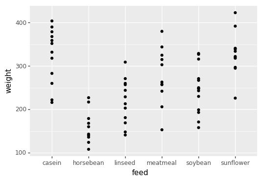

```python
summary = ggplot(data,aes(x="feed",y="weight"))
summary+geom_point()+coord_cartesian()
```

## We need to rearrange the data before we can make hypotheses and test them.

We need to pull out certain pieces of data: for this example we are going to compare chick **weights** from chicks fed either **soybean** or **sunflower** feed. (1)In the **sunflower** list will be chick **weights** from chicks raised on **sunflower** feed and the (2) **soybean** list will include the **weights** from chicks raised on **soybean** feed. Then we will need to (3) combine those lists together. (4) Then we have to replace the feed type (string) with an int value: either 1 or 0. This step is required for hypothesis testing.

```python
#1, 2:
sunflower=data.loc[data.feed.isin(['sunflower']),:]
soybean = data.loc[data.feed.isin(['soybean']),:]

#3:
temp = [sunflower, soybean]
likelihood_df = pd.concat(temp)

#4:
likelihood_df.replace(['sunflower','soybean'],[0,1],inplace=True)
```

## Make hypotheses and test them

Let's test two hypotheses: *(1) the type of **feed** has no effect on chick **weight** (2) the type of **feed** affects the **weight** of the chick*

## test null hypothesis with negative log likelihood function (user-defined)

This is to test hypothesis 1: *that the type of **feed** does not have an effect on chick **weight**.*

```python
def null(p,obs):
    B0=p[0]
    sigma=p[1]
    expected=B0
    nll=-1*norm(expected,sigma).logpdf(obs.weight).sum()
    return nll
```

## test alternative hypothesis with negative log likelihood function (user-defined)

This is to test hypothesis 2: *that the type of **feed (soybean or sunflower)** makes a difference in chick **weight***

```python
def alt(p,obs):
    B0=p[0]
    B1=p[1]
    sigma=p[2]
    expected=B0+B1*obs.feed
    nll=-1*norm(expected,sigma).logpdf(obs.weight).sum()
    return nll
```

## Next we create an array of initial values to run the functions

```python
initialVals=np.array([1,1,1])

fitNull=minimize(null,initialVals,method="Nelder-Mead",options={'disp':True},args=likelihood_df)
fitAlt=minimize(alt,initialVals,method="Nelder-Mead",options={'disp':True},args=likelihood_df)

print (fitNull.x)
print (fitAlt.x)
```

```
Optimization terminated successfully.
         Current function value: 145.240592
         Iterations: 138
         Function evaluations: 261
Optimization terminated successfully.
         Current function value: 138.469162
         Iterations: 230
         Function evaluations: 412
[ 284.49996562   64.53698087  -87.59469238]
[ 328.91663525  -82.48804545   49.73944026]
```

## Finally we determine if there is a statistically significant difference between feed type and chick weights, using a chi-square test

```python
from scipy.stats import chi2

D=(2*(fitNull.fun-fitAlt.fun))
chi2feed=(1-chi2.cdf(x=D,df=1))
print(chi2feed)
```

```
0.000233176728694
```

# The p-value tells us there is a statistically significant difference with p<0.05

We can print a summary statement:

```python
print ("Raising chicks on different feed has a statistically significant effect on resulting chick weight.")
```

```
Raising chicks on different feed has a statistically significant effect on resulting chick weight.
```